# Predicting Breast Cancer Outcomes from Clinical Features and Protein Biomarkers

##### Boxplot - Protein by Histology

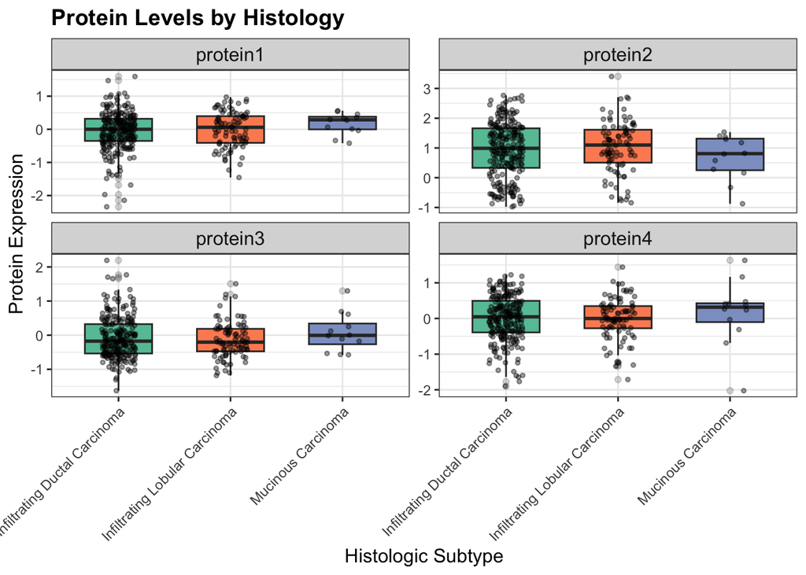

```r
# Identify protein variables
protein_vars <- names(brca)[grepl("^protein", names(brca))]

# Pivot to long format
brca_long_hist <- brca |>
  select(histology, all_of(protein_vars)) |>
  filter(!is.na(histology)) |>
  pivot_longer(
    cols = all_of(protein_vars),
    names_to = "protein",
    values_to = "value"
  )

# Plot
ggplot(brca_long_hist, aes(x = histology, y = value, fill = histology)) +
  geom_boxplot(outlier.alpha = 0.2, width = 0.6) +
  geom_jitter(alpha = 0.4, width = 0.15, size = 1) +
  facet_wrap(~ protein, scales = "free_y") +
  scale_fill_brewer(palette = "Set2") +
  labs(
    title = "Protein Levels by Histology",
    x = "Histologic Subtype",
    y = "Protein Expression"
  ) +
  theme_bw() +
  theme(
    legend.position = "none",
    strip.text = element_text(size = 12),
    axis.text.x = element_text(angle = 45, hjust = 1),
    axis.title = element_text(size = 12),
    plot.title = element_text(size = 14, face = "bold")
  )
```

Across histologic subtypes, protein levels were visually similar with substantial overlap between groups, indicating no detectable expression differences by histology. This is consistent with our non-significant ANOVA results (all adjusted p-values > 0.36).

Final Conclusion: Overall, there was no evidence that protein biomarker expression differed meaningfully by tumour stage or histologic subtype in this dataset. Although there were small differences in average levels, the large amount of variability within groups and the overlap in distributions suggest that these biomarkers do not strongly reflect clinical disease stage or histology on their own. These findings indicate that additional clinical or molecular factors are likely needed to explain differences in disease characteristics, and that the proteins available in this dataset may have limited value as standalone indicators of disease severity.

# 6) Survival analysis

### Time-to-event definition

```r
brca_surv = brca |>
  filter(!is.na(event), !is.na(follow_up_time), follow_up_time >= 0)

# Create Survival object
surv_obj = Surv(time = brca_surv$follow_up_time,
                event = brca_surv$event)
```

### Kaplan–Meier curves

- Overall KM curve.
- Stratified curves (e.g., tumour stage, HER2 status).

#### Kaplan–Meier curves

An overall Kaplan–Meier curve was estimated to describe the distribution of survival time in the cohort. The plot displays the estimated survival probability over follow-up, with 95% confidence bands and a risk table indicating the number of patients at risk at selected time points.

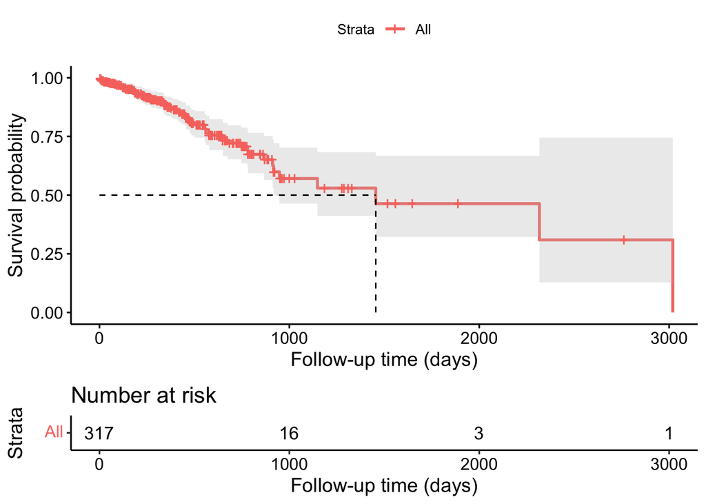

```r
km_overall = survfit(surv_obj ~ 1, data = brca_surv)

ggsurvplot(
  km_overall,
  conf.int = TRUE,
  xlab = "Follow-up time (days)",
  ylab = "Survival probability",
  surv.median.line = "hv",
  risk.table = TRUE
)
```

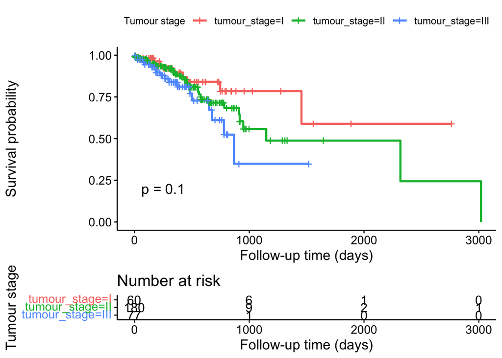

```r
km_stage = survfit(surv_obj ~ tumour_stage, data = brca_surv)

ggsurvplot(
  km_stage,
  data = brca_surv,
  conf.int = FALSE,
  xlab = "Follow-up time (days)",
  ylab = "Survival probability",
  legend.title = "Tumour stage",
  risk.table = TRUE,
  pval = TRUE         # shows log-rank p-value on the plot
)
```

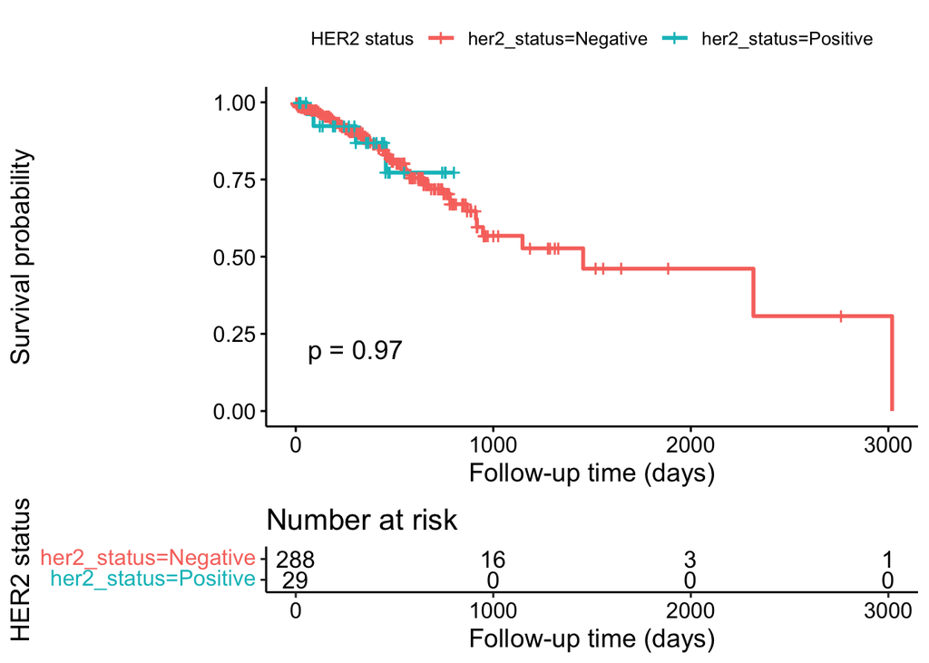

```r
km_her2 = survfit(surv_obj ~ her2_status, data = brca_surv)

ggsurvplot(
  km_her2,
  data = brca_surv,
  conf.int = FALSE,
  xlab = "Follow-up time (days)",
  ylab = "Survival probability",
  legend.title = "HER2 status",
  risk.table = TRUE,
  pval = TRUE
)
```

Kaplan–Meier curves were also stratified by tumour stage (I, II, III) and by HER2 receptor status. These plots allow visual comparison of survival across subgroups. In both cases, a risk table was included to show how many individuals remained under observation at different time points.